# Stat 135: Lab Project

## Question 6

To perform logistic regression, we will first create a logical vector of whether patients have diabetes or not.

```r
diabetic.binary <- as.numeric(glyhb >= 7)
```

Now we can use the built-in glm function in R to help us create a logistic model. We will need to be sure the pass in binomial(logit) as the argument for family, since our model is logistic and our outcome is binary.

```r
standard_features = data.frame(standard_features)
glm.yhat <- glm(diabetic.binary ~ stab.glu + age + bp.1s + WHR + BMI, data = standard_features, family=binomial(logit))
```

Now we can predict the patients' glyhb values with our logistic model.

```r
y_hat2 = predict(glm.yhat, type="response")
```

Now that we have the probabilities for each patient, we need to find a threshold to classify our patients by. In other words, we need a threshold such that a patient with a probability greater than our threshold is classified as having diabetes, and a patient with a probability less than or equal to our threshold is classified as not having diabetes.

Well, our first instinct was to use 0.5 as our threshold and find our Predictive Error Rate, False Positive Rate, and False Negative Rate.

```r
TN = sum(y_hat2 > 0.5 & diabetic.binary) # True negative
FN = sum(y_hat2 < 0.5 & diabetic.binary) # False negative
TP = sum(y_hat2 < 0.5 & !diabetic.binary) # True positive
FP = sum(y_hat2 > 0.5 & !diabetic.binary) # False positive

PER = (FN + FP) / sum(TN + FN + TP + FP)
PER
```

```r
## [1] 0.08077994
```

```r
FPR = FP / (FP + TP)
FPR
```

```r
## [1] 0.02295082
```

```r
FNR = FN / (FN + TN)
FNR
```

```r
## [1] 0.4074074
```

Because we are dealing with a medical condition here, we must be extra sensitive towards our False Negative Rate as telling a patient that they don't have diabetes when they really do is more harmful than telling a patient they have diabetes when they really don't.

So, now let's plot each error rate as a function of probability to help us choose which threshold value works best.

The following function will help us plot these graphs.

```r
errs = function(prob){
TN = sum(y_hat2 > prob & diabetic.binary) # True negative
FN = sum(y_hat2 < prob & diabetic.binary) # False negative
TP = sum(y_hat2 < prob & !diabetic.binary) # True positive
FP = sum(y_hat2 > prob & !diabetic.binary) # False positive

PER = (FN + FP) / (TN + FN + TP + FP)
FPR = FP / (FP + TP)
FNR = FN / (FN + TN)

return(c(PER, FPR, FNR))
}
```

Now let's make a data frame to input in ggplot to help us create these three plots.

```r
x = seq(0, 1, by = 0.01)
y = t(sapply(x, errs))
colnames(y) = c("PER", "FPR", "FNR")
error_data = data.frame(cbind(x = x, y))
head(error_data)
```

```r
##      x       PER       FPR        FNR
## 1 0.00 0.8495822 1.0000000 0.00000000
## 2 0.01 0.7465181 0.8754098 0.01851852
## 3 0.02 0.5766017 0.6754098 0.01851852
## 4 0.03 0.4596100 0.5377049 0.01851852
## 5 0.04 0.3454039 0.4032787 0.01851852
## 6 0.05 0.3008357 0.3475410 0.03703704
```

Now let's plot all three curves on one plot to get a nice visual of what's happening.

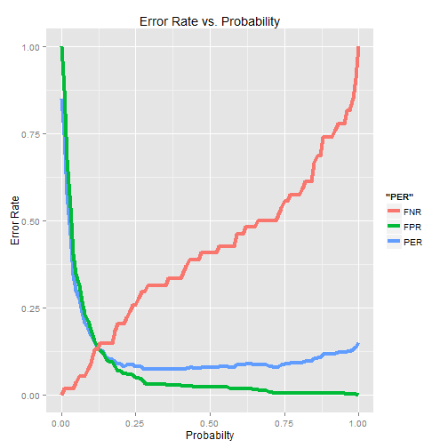

```r
ggplot(error_data, aes(x)) +
  geom_line(aes(y = PER, colour = "PER"), size = 1.5) +
  geom_line(aes(y = FPR, colour = "FPR"), size = 1.5) +
  geom_line(aes(y = FNR, colour = "FNR"), size = 1.5) +
  xlab("Probabilty") +
  ylab("Error Rate") +
  ggtitle("Error Rate vs. Probability")
```

From our visual above, it seems as if a probability of 0.125 will fit best for all three errors in one consideration. This is simply the x value at which all three lines intercept.

So, for our logistic model, we state that if a predicted probability is greater than 0.125, then the patient has diabetes. Otherwise, they do not have diabetes.

With logistic regression, we were able to adjust and make our model more stable. By this, we mean that both error rates and close and we don't sacrifice too much of one for the other.

## Question 7

First let's run our linear model on the test set. We will simply repeat the steps from above.

```r
data_test = read.csv("diabetes_test.csv")
data_test$BMI = 703 * (data_test$weight / (data_test$height)^2)
data_test$WHR = data_test$waist / data_test$hip
features_data2 = data_test[ , c("stab.glu", "age", "bp.1s", "WHR", "BMI")]
y_hat2 = predict(lm.yhat, newdata = features_data2)

y_hat_diabetes = c()
y_hat_diabetes[y_hat2 >= 7] = TRUE
y_hat_diabetes[y_hat2 < 7] = FALSE
data_test$y_hat_diabetes = y_hat_diabetes

y_actual_diabetes = c()
y_actual_diabetes[data_test$glyhb >= 7] = TRUE
y_actual_diabetes[data_test$glyhb < 7] = FALSE
data_test$y_actual_diabetes = y_actual_diabetes

error_table = table(y_hat_diabetes, y_actual_diabetes)
error_table
```

```r
##               y_actual_diabetes
## y_hat_diabetes FALSE TRUE
##          FALSE    12    1
##          TRUE      0    3
```

```r
pred_error = (error_table[2, 1] + error_table[1, 2]) / sum(error_table)
pred_error
```

```r
## [1] 0.0625
```

```r
FPR.test = error_table[2, 1] / sum(error_table[ , 1])
FPR.test
```

```r
## [1] 0
```

```r
FNR.test = error_table[1, 2] / sum(error_table[ , 2])
FNR.test
```

```r
## [1] 0.25
```

Using our linear regression model leads to an overall error prediction rate of 0.0625. The False Positives Rate is 0, and the False Negatives Rate is 0.25.

Now let's use our logistic model where our threshold is 0.125.

```r
standard_features2 = data.frame(cbind(1, apply(features_data2, 2, scale)))
y_hat2 = predict(glm.yhat, newdata = standard_features2, type="response")
```

Now let's use our errs function from above to find the error rates. This will work as we will chang the diabetic.binary vector to the current 16 patients outcome of diabetes and rename the y_hat2 vector to its current values of probabilities.

```r
diabetic.binary = as.numeric(data_test$glyhb >= 7)
errs(0.125)
```

```r
## [1] 0.0625 0.0000 0.2500
```

So we see that our logistic regression model leads to an overall error prediction rate of 0.0625. The False Positives Rates is 0 and the False Negatives Rates is 0.25. These are the exact error rates we got from our linear model.

Thus, neither model did better than the other when applied to our test set. Thus, we do obtain similary performance. This is probably because we used the same training set and because the test set is very small. With only 16 patients in the test set, it is hard to see variance between the two models. Or rather, a difference in any error rate.

Styled with knitrBootstrap